# COVID 19 CASES

TT

2024-05-07

## About the Report

We will be continuing with the covid-19 dataset using in the Lecture. I will be adding two visualizations to check:

- which country has the **most** recorded covid-19 deaths in the dataset.
- List the Top 20 countries with the **most** recorded covid-19 deaths.
- List of 20 countries in order of death-to-cases ratio.

**The libraries used:**

- tidyverse
- lubridate
- knitr

**The datasets used:**

- https://raw.githubusercontent.com/CSSEGISandData/COVID-19/master/csse_covid_19_data/csse_covid_19_time_series/time_series_covid19_confirmed_global.csv
- https://raw.githubusercontent.com/CSSEGISandData/COVID-19/master/csse_covid_19_data/csse_covid_19_time_series/time_series_covid19_deaths_global.csv
- https://raw.githubusercontent.com/CSSEGISandData/COVID-19/master/csse_covid_19_data/csse_covid_19_time_series/time_series_covid19_confirmed_US.csv
- https://raw.githubusercontent.com/CSSEGISandData/COVID-19/master/csse_covid_19_data/csse_covid_19_time_series/time_series_covid19_deaths_US.csv
- https://raw.githubusercontent.com/CSSEGISandData/COVID-19/master/csse_covid_19_data/UID_ISO_FIPS_LookUp_Table.csv

### import data

```r
library(tidyverse)
library(lubridate)
library(knitr)

main_url = "https://raw.githubusercontent.com/CSSEGISandData/COVID-19/master/csse_covid_19_data/csse_covid_19_time_series/"

file_names = c("time_series_covid19_confirmed_global.csv",
"time_series_covid19_deaths_global.csv",
"time_series_covid19_confirmed_US.csv",
"time_series_covid19_deaths_US.csv")

urls <- str_c(main_url, file_names)

global_cases <- read_csv(urls[1])
global_deaths <- read_csv(urls[2])
us_cases <- read_csv(urls[3])
us_deaths <- read_csv(urls[4])
```

## tidy the data

```r
global_cases <- global_cases %>%
  pivot_longer(cols = -c('Province/State',
                         'Country/Region', Lat, Long),
               names_to = "date",
               values_to = "cases") %>%
  select(-c(Lat,Long))

global_deaths <- global_deaths %>%
  pivot_longer(cols = -c('Province/State',
                         'Country/Region', Lat, Long),
               names_to = "date",
               values_to = "deaths") %>%
  select(-c(Lat,Long))

global <- global_cases %>%
  full_join(global_deaths) %>%
  rename(Country_Region = `Country/Region`,
         Province_State = `Province/State`) %>%
  mutate(date = mdy(date))
global <- global %>% filter(cases > 0)

summary(global)
```

```
##  Province_State     Country_Region          date                cases
##  Length:306827      Length:306827      Min.   :2020-01-22   Min.   :        1
##  Class :character   Class :character   1st Qu.:2020-12-12   1st Qu.:     1316
##  Mode  :character   Mode  :character   Median :2021-09-16   Median :    20365
##                                        Mean   :2021-09-11   Mean   :  1032863
##                                        3rd Qu.:2022-06-15   3rd Qu.:   271281
##                                        Max.   :2023-03-09   Max.   :103802702
##      deaths
##  Min.   :      0
##  1st Qu.:      7
##  Median :    214
##  Mean   :  14405
##  3rd Qu.:   3665
##  Max.   :1123836
```

```r
# check if maximum values seem correct
# global %>% filter(cases > 100000000)


# tidy us data
us_cases <- us_cases %>%
  pivot_longer(cols = -(UID:Combined_Key),
               names_to = "date",
               values_to = "cases") %>%
  select(Admin2:cases) %>%
  mutate(date = mdy(date)) %>%
  select(-c(Lat, Long_))

us_deaths <- us_deaths %>%
  pivot_longer(cols = -(UID:Population),
               names_to = "date",
               values_to = "death") %>%
  select(Admin2:death) %>%
  mutate(date = mdy(date)) %>%
  select(-c(Lat, Long_))

us <- us_cases %>%
  full_join(us_deaths)
```

[output not shown]

```r
global <- global %>%
  unite("Combined_Key",
        c(Province_State, Country_Region),
        sep = ", ",
        na.rm = TRUE,
        remove = FALSE)

uid_lookup_url <- "https://raw.githubusercontent.com/CSSEGISandData/COVID-19/master/csse_covid_19_data/UID_ISO_FIPS_LookUp_Table.csv"

uid <- read_csv(uid_lookup_url) %>%
  select(-c(Lat, Long_, Combined_Key, code3, iso2, iso3, Admin2))
global <- global %>%
  left_join(uid, by = c("Province_State", "Country_Region")) %>%
  select(-c(UID, FIPS)) %>%
  select(Province_State, Country_Region, date,
         cases, deaths, Population,
         Combined_Key)
```

### Top 20 Countries most Death

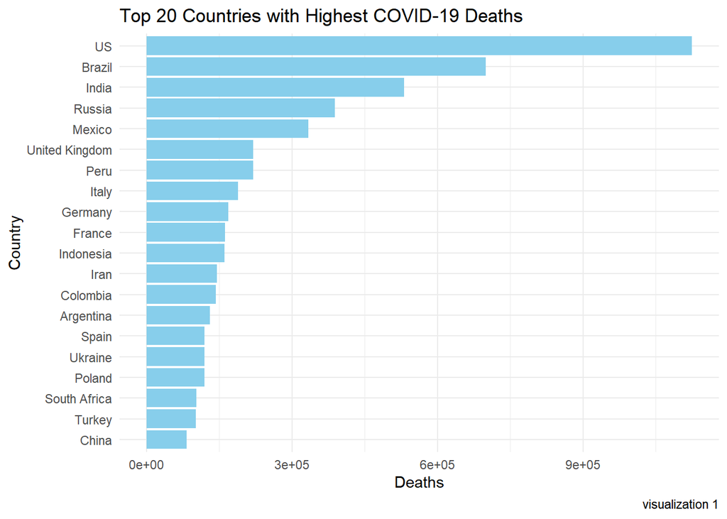

```r
# let's show top 20 results, more results is hard to see on the graph.
top_20_countries <- global %>%
  group_by(Country_Region) %>%
  summarize(max_deaths = max(deaths, na.rm = TRUE)) %>%
  top_n(20, max_deaths)

# Sort the top 20 countries by maximum deaths in descending order
top_20_countries <- top_20_countries[order(-top_20_countries$max_deaths),]

# Create a plot
ggplot(top_20_countries, aes(x = reorder(Country_Region, max_deaths), y = max_deaths)) +
  geom_bar(stat = "identity", fill = "skyblue") +
  coord_flip() +
  labs(x = "Country", y = "Deaths", title = "Top 20 Countries with Highest COVID-19 Deaths",
       caption = "visualization 1") +
  theme_minimal()
```

## Below is the modal of the data (most Deaths):

The model of data showing countries with the most recorded covid-19 deaths:

```r
kable(top_20_countries)
```

| Country_Region | max_deaths |
| --- | --- |
| US | 1123836 |
| Brazil | 699276 |
| India | 530779 |
| Russia | 388478 |
| Mexico | 333188 |
| United Kingdom | 219948 |
| Peru | 219539 |
| Italy | 188322 |
| Germany | 168935 |
| France | 161512 |
| Indonesia | 160941 |
| Iran | 144933 |
| Colombia | 142339 |
| Argentina | 130472 |
| Spain | 119479 |
| Ukraine | 119283 |
| Poland | 119010 |
| South Africa | 102595 |
| Turkey | 101492 |
| China | 82195 |